# anchoredDistr

## Applying MAD

The `anchoredDistr` package can take this information and calculate the posterior of the random parameter in question based on requested inversion data. Below, the 100th time step is used as the inversion data, then the posterior is calculated and plotted (again, using the `plotMAD` function).

```r
pumping <- calcLikelihood(pumping, 100)
pumping <- calcPosterior(pumping)
```

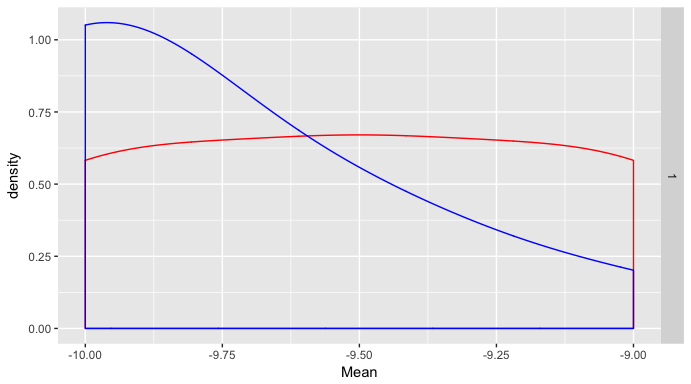

```r
plotMAD(pumping, "posteriors")
```

## Applying MAD with Dimension Reduction

The `anchoredDistr` package can take this information and calculate the posterior of the random parameter in question based on requested inversion data. Below, the minimum value in the time series is used as the inversion data, then the posterior is calculated and plotted (again, using the `plotMAD` function). This is the same as using the 100th time step, but showcasing the ability to provide a function instead of a subset for the reduction.

```r
pumping.min <- reduceData(pumping, min)
pumping.min <- calcLikelihood(pumping.min)
pumping.min <- calcPosterior(pumping.min)
```

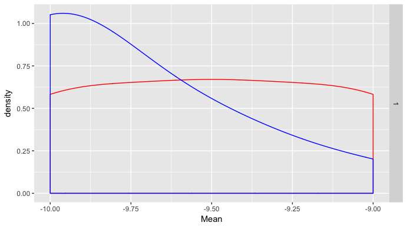

```r
plotMAD(pumping.min, "posteriors")
```

Even more complicated functions can be passed. For example, this `matern` function:

```r
matern <- function(x, params){
  sigma <- params[1]
  lambda <- params[2]
  kappa <- params[3]
  t <- sqrt(2*kappa)*x/lambda
  cov <-  ((sigma*(t^kappa)/gamma(kappa))*2^(1-kappa))*besselK(t,kappa)
  return(sigma-cov)
}
```

If we want to fit this `matern` function to the time series, we need to provide `nls` with initial values for the three parameters. Here is a function to estimate these initial values:

```r
init.matern <- function(x){
  params<- c()
  params[1] <- min(x)
  params[2] <- min(10, tail(which(x > 0.3*min(x)),1))
  params[3] <- 0.5
  return(params)
}
```

We can pass these two functions to `reduceData` for fitting a matern model to each time series and performing the inversion with the three parameters:

```r
pumping.matern <- reduceData(pumping, matern, init.matern, lower=c(-Inf,1,0.1), upper=c(0,100,5), algorithm="port")
```

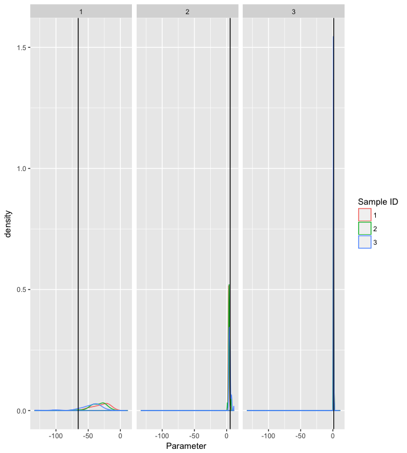

```r
plotMAD(pumping.matern, "realizations")
```

```r
pumping.matern <- calcLikelihood(pumping.matern)
pumping.matern <- calcPosterior(pumping.matern)
```

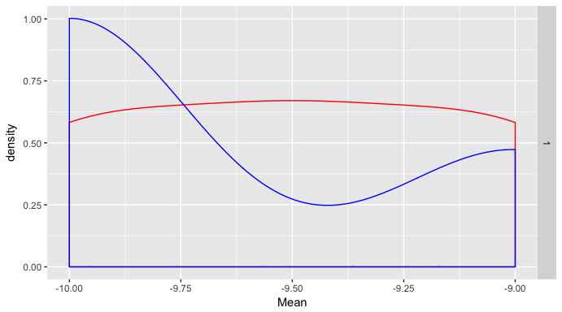

```r
plotMAD(pumping.matern, "posteriors")
```

## Convergence testing

In order to assess the convergence of the likelihood values, you can call the `testConvergence` function that will take a MADproject object and calculate likelihood values for a range of realization counts.

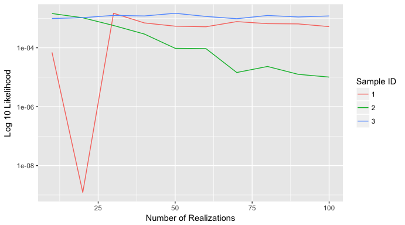

```r
testConvergence(pumping.matern)
```